# PAC2 Visualització de Dades Voronoi, BeeSwarm i Bubblechart

# 3 Bubble chats o diagrames de bombolles

*Informació inspirada en [https://en.wikipedia.org/wiki/Bubble_chart]*

El diagrama de bombolles és una tècnica pensada per a representar ternes d’atributs (o fins i tot grups de quatre atributs si juguem amb el color). Dos dels atributs es representen mitjançant la posició del centre del cercle i el tercer atribut es representa mitjançant l’àrea del cercle.

Utilitzar bombolles (cercles) per a representar valors pot resultar confús. El sistema visual humà de forma natural jutja la mida d’un cercle més en funció del diàmetre que de l’àrea(1). Per tant, pot resultar més convenient associar la tercera variable a representar amb el radi o diàmetre del cercle en lloc de l’àrea. De fet, la majoria de software gràfic demanen treballar amb el radi/diàmetre.

Aquest problema pot portar a greus confusions especialment en el cas d’un ampli rang de valors. Com que molta gent desconeix el problema, els que sí estan al cas sovint dubten en la interpretació al desconèixer si els cercles tenen l’escalat correcte(2). La solució consisteix, o bé deixar constància escrita de quina magnitud s’ha fet servir en l’escalat o bé utilitzar tècniques interactives per a fer aparèixer el valor real associat al cercle quan, per exemple, posem el ratolí a sobre.

1. Raidvee et al., 2020 “Perception of means, sums, and areas”[https://link.springer.com/content/pdf/10.3758/s13414-019-01938-7.pdf]
2. Edward Tufte, The Visual Display of Quantitative Information. Cheshire, CT: Graphics Press. (2001, 2nd edition, ISBN 0-9613921-4-2)

Com aplicació del gràfic de bombolles prendrem un conjunt de dades força conegut: La relació entre esperança de vida i renda per càpita de cada pais, i com tercera variable la població de cada pais. Les dades es troben en la llibreria gapminder de R. Corresponen a l’any 2007 i tenen com a possible quarta variable el continent del pais

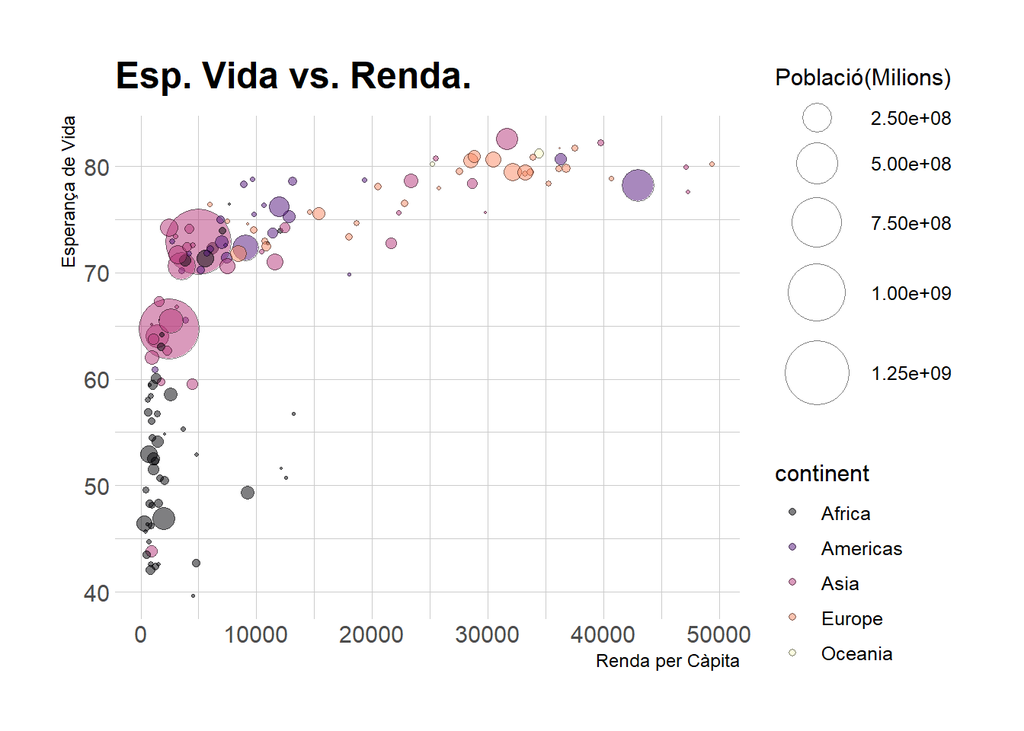

```r
# Carrega paleta perceptualment uniforme i adequada per als cecs de color
library(viridis)
library(hrbrthemes)

# Càrrega de les dades
library(gapminder)
data <- gapminder %>% filter(year=="2007") %>% dplyr::select(-year)

# Gràfic. Estem prenent scale_size, que és el diàmetre per associar-lo a la
# població, escalant el rang de poblacions a un rang de mides de diàmetres.
# Podriem haver treballat amb scale_radius(molt semblant) o scale_area(amb els problemes comentats)

ggplot(data) +
  aes(x=gdpPercap, y=lifeExp, size=pop, fill=continent) +
  geom_point(alpha=0.5, shape=21, color='black') +
  scale_size(range = c(.1, 15), name="Població(Milions)") +
  scale_fill_viridis(discrete=TRUE, option="A") +
  guides(colour = "colorbar", size = "legend", shape = "legend") +
  theme_ipsum() +
  theme(legend.position="right") +
  ggtitle("Esp. Vida vs. Renda.") +
  labs(x = 'Renda per Càpita', y = 'Esperança de Vida')
```

# 4 Beeswarm

*Informació inspirada en [https://en.wikipedia.org/wiki/Box_plot]*

La tècnica Beeswarm és una variant de la tècnica de Boxplot. Un altre exemple de tècnica similar seria el gràfic de violí.

És un gràfic que subministra la informació dels valors mínim i màxim, dels quartils Q1, mediana i Q3, dels valors extrems en l’interval d’observacions típiques, i dels outliers. Amb aquestes dades, n’hi ha prou per veure a cop d’ull aspectes importants de la distribució: per exemple, que la mediana no estigui centrada en el rectangle indica una distribució asimètrica.

Un dels avantatges de la representació de caixes és que és una representació no-paramètrica; no fa cap suposició respecte la distribució de probabilitat subjacent a la mostra.

Un altre avantatge és que es poden juxtaposar diferents beeswarms per a poder-los comparar ja que no ocupen gaire lloc. Aquesta és una de les propietats de ggplot, les facets, que podrem utilitzar.

A diferència de la Boxplot que treballa amb una amplada de caixa fixa i per tant no dóna compte de la modalitat de la mostra, tant la tècnica de violí com la de beeswarm van variar l’amplada de la caixa. El violí ho fa de forma continua, ajustant una hipotètica distribució continua a les mostres i juxtaposant punts discrets (amb un cert valor random per tal d’evitar la superposició i donar més amplada) als valors amb major freqüència.

Per a veure com funciona, generaré quatre distribucions aleatòries.

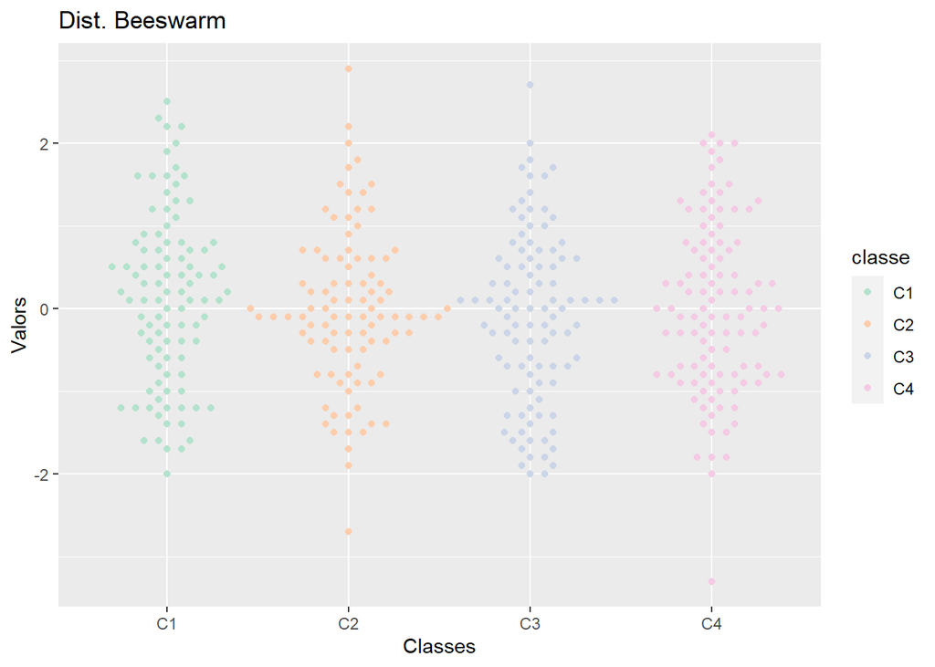

```r
# y = 400 valors Dist N(0, 1) arrodonits a 1 decimal
y = round(rnorm(400), 1)

# Creem un dataframe amb dues columnes i assigno els y a un dels 4 grups mostrejos
df <- data.frame(y = y, classe = sample(c('C1', 'C2', 'C3', 'C4'),
                    size = 400, replace = TRUE))

# Cridem a la llibreria adequada
library(ggbeeswarm)

# generem el gràfic
ggplot(df) +
  aes(x = classe, y = y, color=classe) +
  geom_beeswarm(cex=2) +
  scale_color_brewer(palette = 'Pastel2') +
  ggtitle('Dist. Beeswarm') +
  labs(x = 'Classes', y = 'Valors')
```

Existeixen múltiples opcions de cara a la distribució dels punts.

Una primera opció és, com hem fet, utilitzar el paràmetre cex. El paràmetre cex ens és útil per a aplicar als punts que cauen en el mateix valor de les ordenades un cert desplaçament horitzontal. Així, evitem la superposició dels punts coincidents i donem informació de com de poblat (freqüència) està aquell valor de les ordenades.

Un altre punt a tenir en compte amb aquesta funció és que el resultat pot dependre de amb quin ordre llegim els punts en el fitxer. Existeixen diferents opcions del paràmetre priority de geom_beeswarm com ara: “ascending”(defecte), “descending”, “density”, “random” y “none”.

Es pot també, per tal d’evitar el solapament, afegir soroll quasi-aleatori utilitzant la funció geom_quasirandom() en lloc de la geom_beeswarm().

Es pot també variar el mètode de distribució de punts. Per defecte, geom_quasirandom utilitza quasi_random, però també hi ha “pseudo_random”, “smiley”, i “frowney”. Per a veure l’efecte, represento les mateixes dades d’abans però amb aquests dos darrers paràmetres

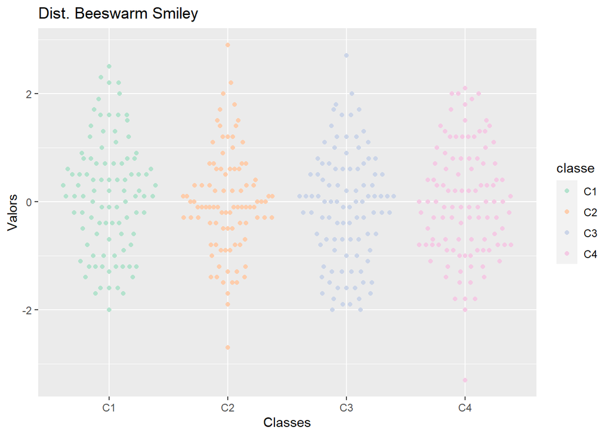

```r
# generem el gràfic smiley
ggplot(df) +
  aes(x = classe, y = y, color=classe) +
  geom_quasirandom(method='smiley') +
  scale_color_brewer(palette = 'Pastel2') +
  ggtitle('Dist. Beeswarm Smiley') +
  labs(x = 'Classes', y = 'Valors')
```

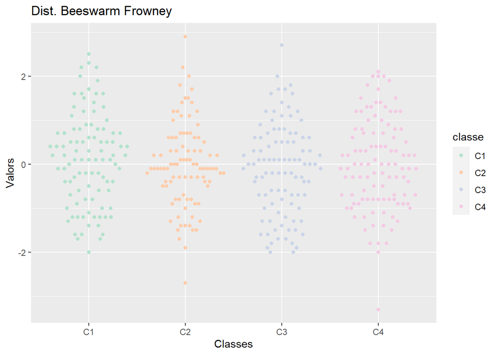

```r
# generem el gràfic smiley
ggplot(df) +
  aes(x = classe, y = y, color=classe) +
  geom_quasirandom(method='frowney') +
  scale_color_brewer(palette = 'Pastel2') +
  ggtitle('Dist. Beeswarm Frowney') +
  labs(x = 'Classes', y = 'Valors')
```